# Group Data Analysis

Group hisa’R’üstü

After the 92nd row, rows gives information about the numerical . Therefore, numerical data was separated from these information rows and put into another data set.

The home sales data included data with zeros after the comma. To avoid these problems, zeros are cleared from the data after the comma.

```r
for(i in c(1:165)){
  evds[,i] <- gsub(",","",evds[,i])
}
evds[, c(2:165)] <- sapply(evds[, c(2:165)], as.numeric)
names(evds)[1] = "Date"
```

In order to convert the Date column to a date format, it was necessary to add days to the Date. That’s why the day was added to the Date column.

```r
evds$Date = paste(evds$Date,"01",sep="-")
evds = evds %>%
  mutate(Date=as.Date(Date, format="%Y-%m-%d")) %>%
  mutate(Year=year(Date), Month=month(Date))
```

In the data analysis process, a season column may be required to examine the relationship between sales data and seasons, so the season column was created.

```r
find_season <- function(mon){
  season = NULL

  if(between(mon, 3, 5)){
    season = "Spring"
  } else if(between(mon, 6, 8)){
    season = "Summer"
  } else if(between(mon, 9, 11)){
    season = "Fall"
  } else{
    season = "Winter"
  }

  return(season)
}
evds$Season = sapply(evds$Month, find_season)
```

When the data is checked carefully, there is some missing data. To guess what these missing data are: Total data was analyzed by collecting all data. As it is realized that it is equal, empty data (NA) are accepted as 0.

```r
evds[,c(2)] - rowSums(evds[,c(3:83)], na.rm = FALSE)
```

```
##  [1]  0  0 NA  0  0  0  0  0  0  0  0  0  0 NA  0  0  0  0  0  0  0  0  0  0  0
## [26]  0  0  0  0  0  0  0  0  0  0  0  0 NA  0  0 NA  0 NA  0  0  0  0  0  0  0
## [51]  0  0  0 NA  0  0  0  0  0  0  0  0  0  0  0  0  0  0  0  0  0  0  0  0 NA
## [76]  0  0  0  0  0  0  0  0  0  0  0  0  0  0  0  0
```

```r
evds[,c(2)] - rowSums(evds[,c(3:83)], na.rm = TRUE)
```

```
##  [1] 0 0 0 0 0 0 0 0 0 0 0 0 0 0 0 0 0 0 0 0 0 0 0 0 0 0 0 0 0 0 0 0 0 0 0 0 0 0
## [39] 0 0 0 0 0 0 0 0 0 0 0 0 0 0 0 0 0 0 0 0 0 0 0 0 0 0 0 0 0 0 0 0 0 0 0 0 0 0
## [77] 0 0 0 0 0 0 0 0 0 0 0 0 0 0 0
```

```r
evds[is.na(evds)] <- 0
```

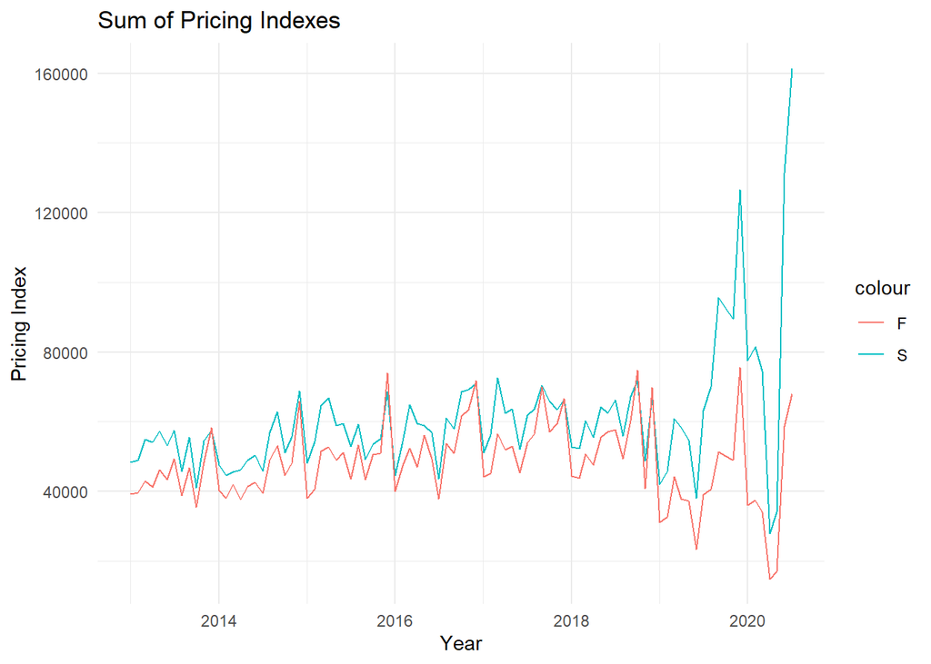

```r
write.xlsx(evds, file = "processedData.xlsx", append = FALSE)


ggplot(evds, aes(x=Date)) +
  geom_line(aes(y=S_Turkey, color="S")) +
  geom_line(aes(y=F_Turkey, color="F")) +
  theme_minimal() +
  ggtitle("Sum of Pricing Indexes") +
  labs(x = "Year", y = "Pricing Index")
```

Turkey the behavior of sales in general, the city has been interpreted by comparing the behavior of a relationship between them. As can be seen in the graph, the sales behavior of Adana is similar to the sales data across the country. We cannot generalize for every city, but we can say that the same criteria are effective across the country.

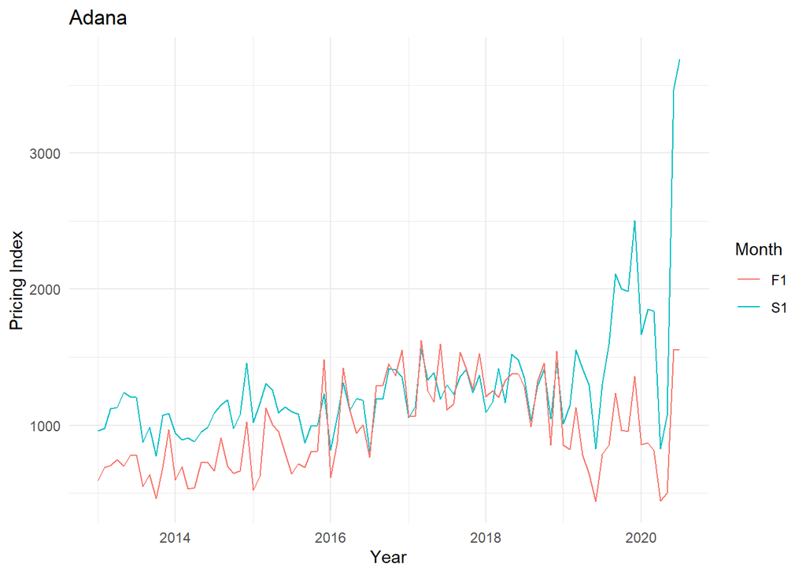

```r
ggplot(evds, aes(x=Date, color = Month)) +
  geom_line(aes(y=S_Adana, color="S1")) +
  geom_line(aes(y=F_Adana, color="F1")) +
  theme_minimal() +
  ggtitle("Adana") +
  labs(x = "Year", y = "Pricing Index")
```

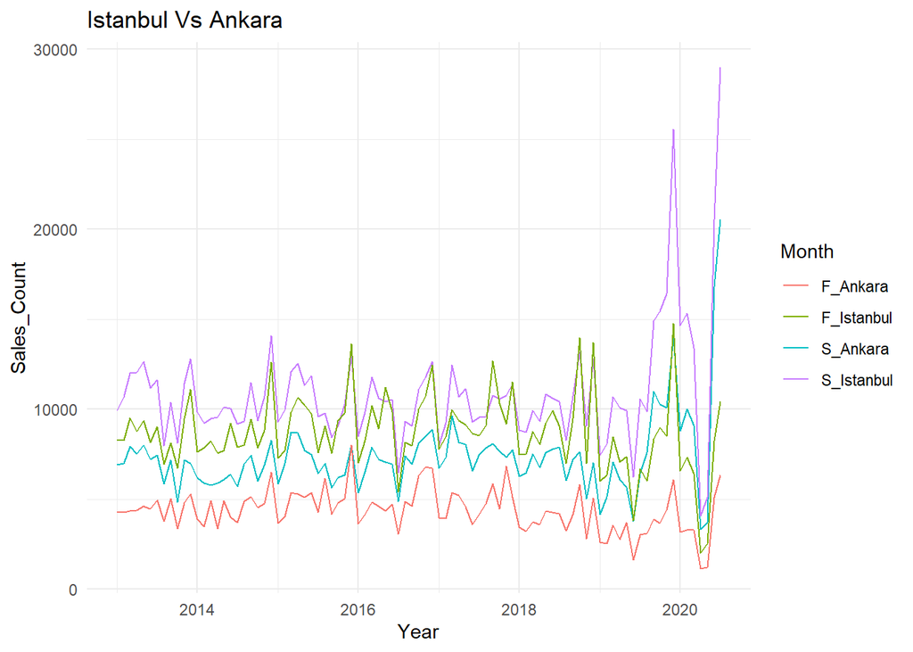

```r
ggplot(evds, aes(x=Date, color = Month)) +
  geom_line(aes(y=S_Ankara, color="S_Ankara")) +
  geom_line(aes(y=F_Ankara, color="F_Ankara")) +
  geom_line(aes(y=S_Istanbul, color="S_Istanbul")) +
  geom_line(aes(y=F_Istanbul, color="F_Istanbul")) +
  theme_minimal() +
  ggtitle("Istanbul Vs Ankara") +
  labs(x = "Year", y = "Sales_Count")
```

```r
evds2 = evds
evds2[,c(2:83)] = evds2[,c(2:83)]*100/evds2[,2]
evds2[,c(84:165)] = evds2[,c(84:165)]*100/evds2[,84]
```

In order to examine the house sales data of the Aegean ve Akdeniz region, whose population has increased considerably during the summer season, some of the cities in the Aegean and Akdeniz Region were selected from all data. (Antalya, Balıkesir, İzmir, Aydın, )

```r
ege_bolge <- evds[,c(1,10,14,43,13,61,166,167,168)]
head(ege_bolge)
```

```
##         Date F_Antalya F_Balikesir F_Izmir F_Aydin F_Mugla Year Month Season
## 1 2013-01-01      2101         639    2189     651     389 2013     1 Winter
## 2 2013-02-01      1896         693    2225     636     420 2013     2 Winter
## 3 2013-03-01      2374         751    2461     991     478 2013     3 Spring
## 4 2013-04-01      2188         847    2331     793     443 2013     4 Spring
## 5 2013-05-01      2535         858    2514     770     451 2013     5 Spring
## 6 2013-06-01      1883         804    2599     667     483 2013     6 Summer
```

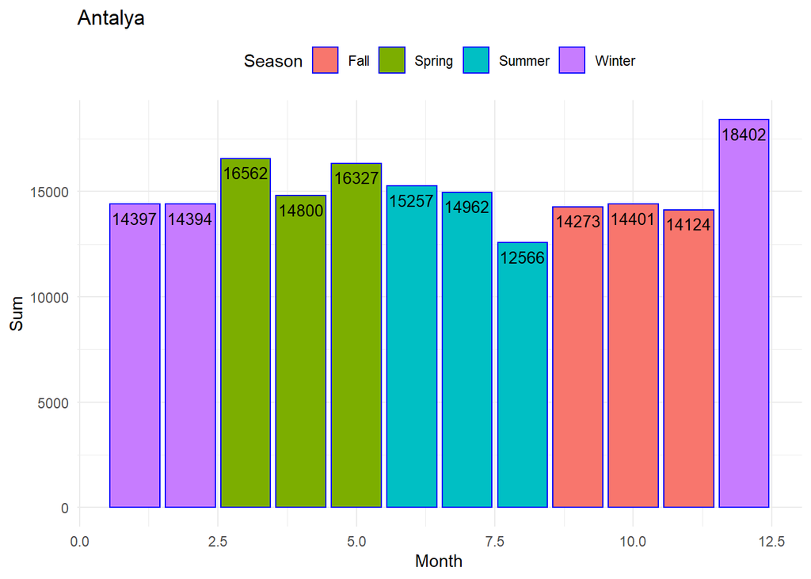

```r
ege_bolge %>%  group_by(Month,Season) %>% summarise(Sum = sum(F_Antalya)) %>%
  ggplot(data = ., aes(x = Month, y = Sum, fill = Season)) +
  geom_bar(stat="identity", position = position_dodge(), colour = "blue") +
  theme_minimal() +
  theme(legend.position="top")+
  labs(title = "Antalya")+
  geom_text(aes(label=Sum), vjust=1.6, color="black",
      position = position_dodge(0.9), size=3.5)
```

[figure not shown]

```r
ggplot(ege_bolge, aes(x=Month, y = ege_bolge[,c(2:2)], group = Year, colour = Season)) +
  geom_line() +
  theme_minimal() +
  theme(legend.position="top")+
  labs(title = "Balikesir",y="Monthly Index")
```

First and second hand sales data between Ankara and Istanbul by years.

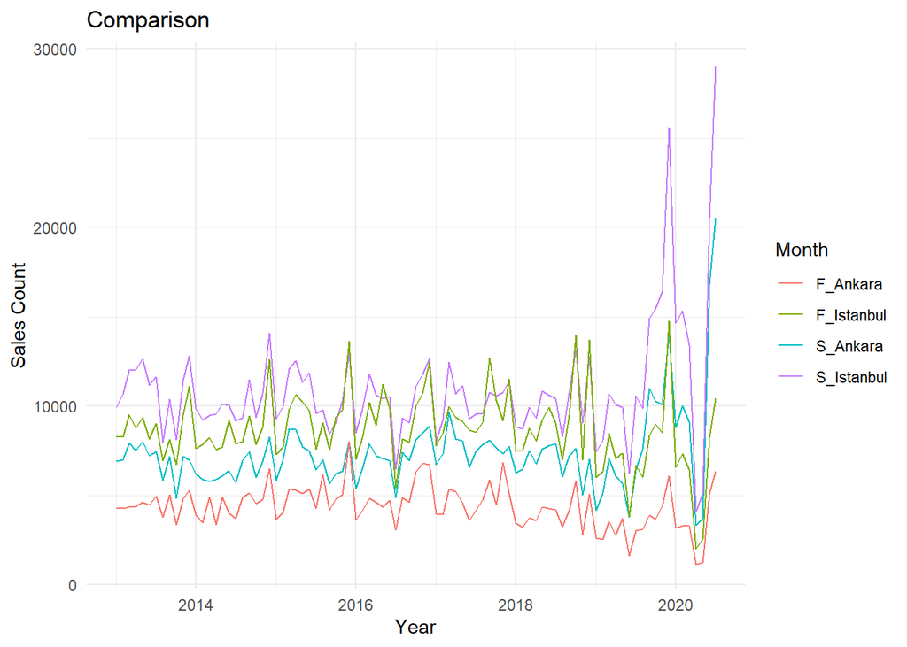

```r
ggplot(evds, aes(x=Date, color = Month)) +
  geom_line(aes(y=S_Ankara, color="S_Ankara")) +
  geom_line(aes(y=F_Ankara, color="F_Ankara")) +
  geom_line(aes(y=S_Istanbul, color="S_Istanbul")) +
  geom_line(aes(y=F_Istanbul, color="F_Istanbul")) +
  theme_minimal() +
  ggtitle("Comparison") +
  labs(x = "Year", y = "Sales Count")
```

Total sales dates by years and seasons by selected cities in the aegean region with bar chart

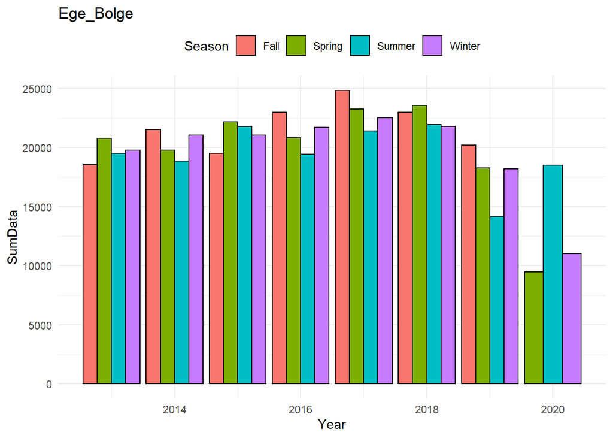

```r
#
ege_bolge %>% group_by(Year,Season) %>% summarise(SumData=sum(F_Antalya, F_Balikesir, F_Izmir, F_Aydin, F_Mugla)) %>%
    ggplot(data = ., aes(x = Year, y = SumData, fill = Season)) +
      geom_bar(stat="identity", position = position_dodge(), colour = "black") +
      theme_minimal() +
      theme(legend.position="top")+
      labs(title = "Ege_Bolge")
```

### Clustering by Housing Price Index

By classifying the sales data of the cities according to the similarities of the movement, it is desired to analyze the sales behavior more logically. Therefore, all columns are scaled.

First hand only city columns are scaled so that they are grouped by movement similarities.

Only Second hand city columns are scaled so that they are grouped according to their motion similarity.

First hand only city columns used, not scaled so often grouped by size of numbers

evds2 contains what percentage of the values make up the total, maybe abnormal changes may be caught / a result may be reached:

```r
createCluster<-function(data2,clusterSize,scale=TRUE){
  data<-data2

  if(scale){
    data<-scale(data)
  }
  set.seed(2)
  fit <- kmeans(t(data), clusterSize)
  return(fit$cluster)
}


clusters = tibble(TUR@data$NAME_1)
names(clusters)=c("city")
clusterSize=5

clusters<-cbind(clusters,createCluster(evds[,c(3:83)],clusterSize))
clusters<-cbind(clusters,createCluster(evds[,c(3:83)],clusterSize,scale=FALSE))
clusters<-cbind(clusters,createCluster(evds[,c(85:165)],clusterSize))
clusters<-cbind(clusters,createCluster(evds[,c(85:165)],clusterSize,scale=FALSE))
clusters<-cbind(clusters,createCluster(evds[,c(85:165)]-evds[,c(3:83)],clusterSize))
names(clusters)<-c("city","scaledFirst","First","scaledSecond","Second","firstMinusSecond")
row.names(clusters)<-NULL
```

```r
mapPlot<-function(x,z,mapPositions){

mapPositions2<-cbind(mapPositions,x)

ab<-cbind(c(1:81),mapPositions2)
ab[,1]=as.character(ab[,1])
colnames(ab)[1]="id"

final_map <- left_join(TUR_fixed, ab, by = "id")


ggplot(final_map)+
  theme_minimal()+
  geom_polygon( aes_string(x = "long", y = "lat", group = "group", fill= z),
                color = "grey", alpha = 1/5) +
  coord_map()+
  scale_fill_distiller(name = paste(paste("Cities by",z),"Hand Housing Price Index"), # change titel legend
                       palette = "Spectral")+ # change the color scheme
  theme(legend.position = "bottom") # chagne the legend position

}
```

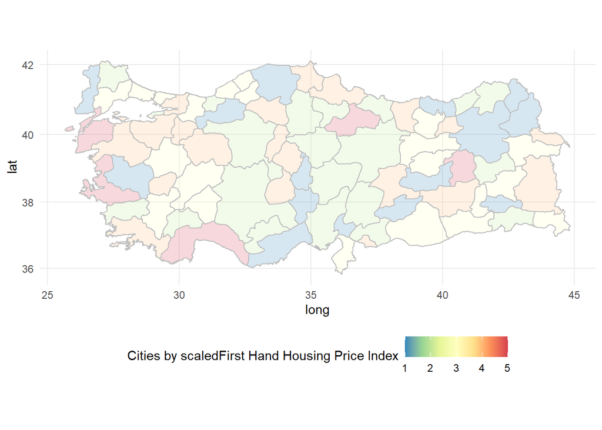

```r
mapPlot(clusters[,c(2:5)],"scaledFirst",mapPositions)
```

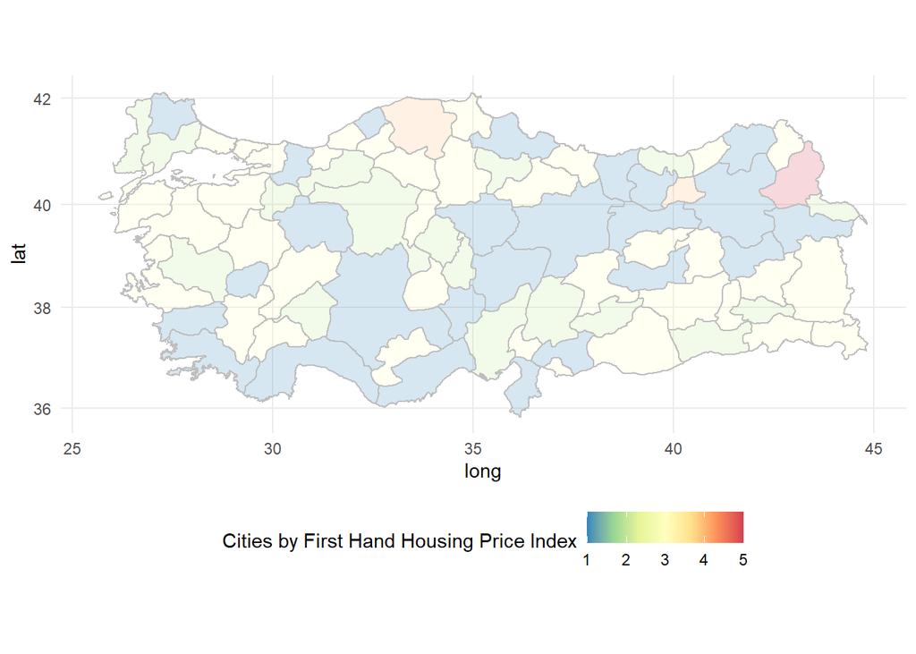

```r
mapPlot(clusters[,c(2:5)],"First",mapPositions)
```

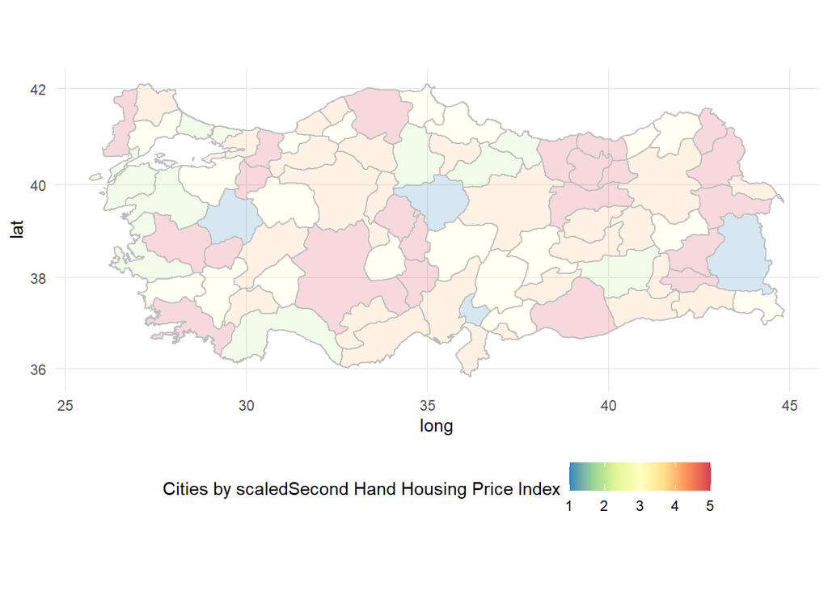

```r
mapPlot(clusters[,c(2:5)],"scaledSecond",mapPositions)
```

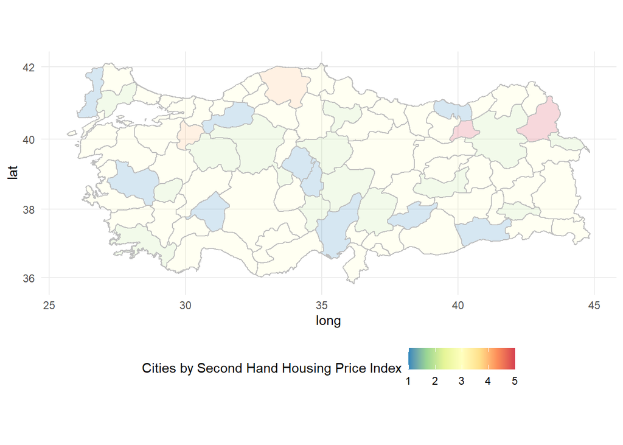

```r
mapPlot(clusters[,c(2:5)],"Second",mapPositions)
```

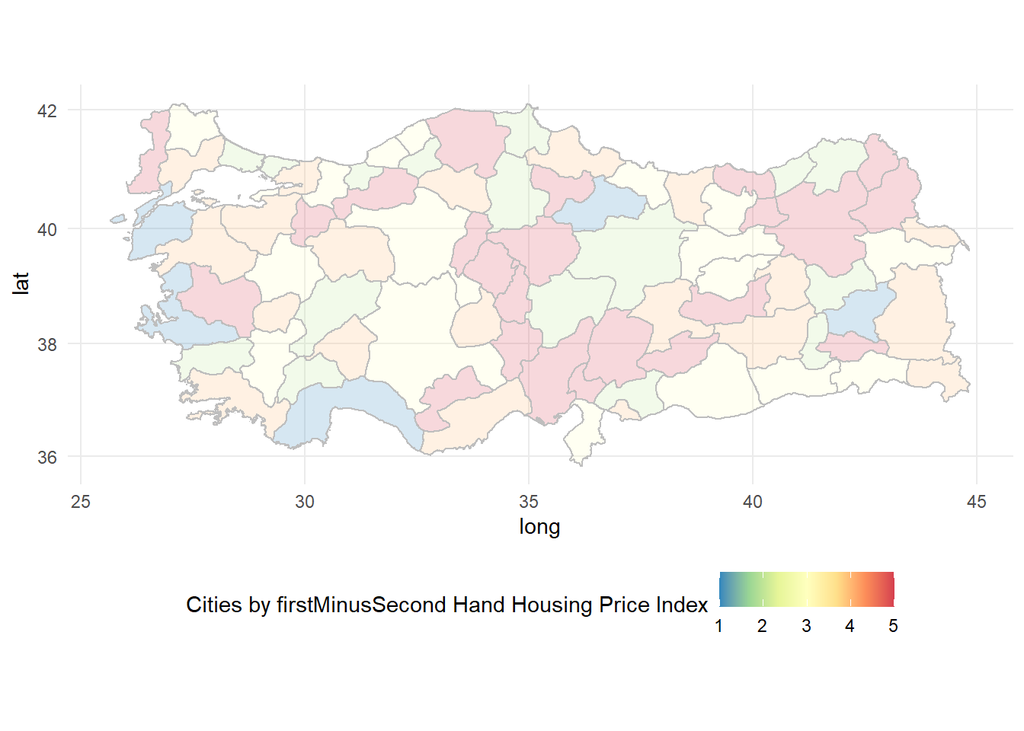

```r
mapPlot(clusters[,c(2:6)],"firstMinusSecond",mapPositions)
```

İstanbul, Ankara, Adana, Kayseri, Antalya, Bursa, Eskişehir, Mersin, Van are among the largest 30 cities in Turkey. To see the difference between first-hand and second-hand prices, the means of their respective price index are calculated. As a common fact, first-hand prices are higher than the second-hand prices. However, Van shows an exceptional result as its second-hand price is higher. The plot is generated to show how large the difference is among these cities. Ankara and İstanbul are the leading cities in terms of the price gap, with Ankara on top and İstanbul the runner-up.

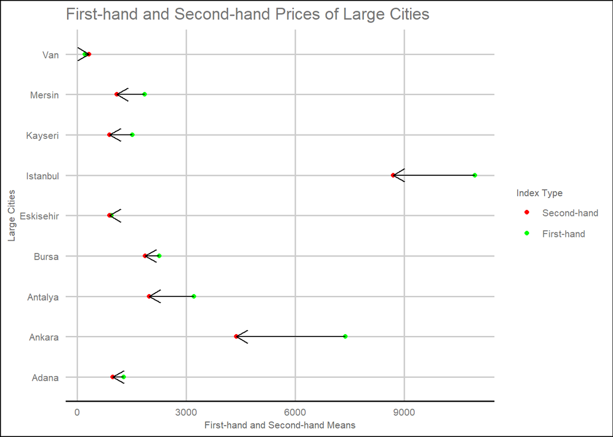

```r
S_means <- c(mean(evds$S_Istanbul),mean(evds$S_Ankara),mean(evds$S_Adana),mean(evds$S_Kayseri),mean(evds$S_Antalya),mean(evds$S_Bursa),mean(evds$S_Eskisehir), mean(evds$S_Mersin),mean(evds$S_Van))
F_means <- c(mean(evds$F_Istanbul),mean(evds$F_Ankara),mean(evds$F_Adana),mean(evds$F_Kayseri),mean(evds$F_Antalya),mean(evds$F_Bursa),mean(evds$F_Eskisehir), mean(evds$F_Mersin),mean(evds$F_Van))
cities<- c("Istanbul","Ankara","Adana","Kayseri","Antalya","Bursa","Eskişehir","Mersin","Van")
large_city_data <- data.frame(cities, S_means, F_means)

ggplot(large_city_data)+
  geom_point(aes(S_means,cities,color="red"))+
  geom_point(aes(F_means,cities,color="green"))+
  geom_segment(aes(x = S_means,y = cities,xend = F_means,yend = cities,),arrow=arrow(length = unit(0.15, "inches")))+
  theme_gdocs()+
  labs(x="First-hand and Second-hand Means", y="Large Cities", title="First-hand and Second-hand Prices of Large Cities")+
  scale_color_manual(name="Index Type",labels=c("Second-hand","First-hand"),values=c("red","green"))+
  theme(
    text= element_text(size=8, color="black")

  )
```